# hw_9

Holden Mitchell

11/2/2017

## Chapter 10

10-15, 10-21, 10-39, 10-44, 10-51, 10-63, 64, 65, 66, 10-69, 70, 11-4 (Ch. 11) Risk and Return (group)

#### 10-15

```r
inflation = c(1,2,12.6,-10.3,0.51,2.03,-1.8,5.79,5.87)
return = c(-3,36,12,-8,53,-2,18,32,24)

data = data.frame("inflation" = inflation, "return" = return)

linearMod = lm(return ~ inflation, data = data)
summary(linearMod)
```

```
##
## Call:
## lm(formula = return ~ inflation, data = data)
##
## Residuals:
##     Min      1Q  Median      3Q     Max
## -20.064 -16.294   2.221  10.299  36.410
##
## Coefficients:
##             Estimate Std. Error t value Pr(>|t|)
## (Intercept)  16.0961     7.3288   2.196   0.0641 .
## inflation     0.9681     1.1829   0.818   0.4401
## ---
## Signif. codes:  0 '***' 0.001 '**' 0.01 '*' 0.05 '.' 0.1 ' ' 1
##
## Residual standard error: 20.85 on 7 degrees of freedom
## Multiple R-squared:  0.08732,    Adjusted R-squared:  -0.04306
## F-statistic: 0.6697 on 1 and 7 DF,  p-value: 0.4401
```

```r
anova1 <- aov(linearMod)
summary (anova1)
```

```
##             Df Sum Sq Mean Sq F value Pr(>F)
## inflation    1  291.1   291.1    0.67   0.44
## Residuals    7 3042.9   434.7
```

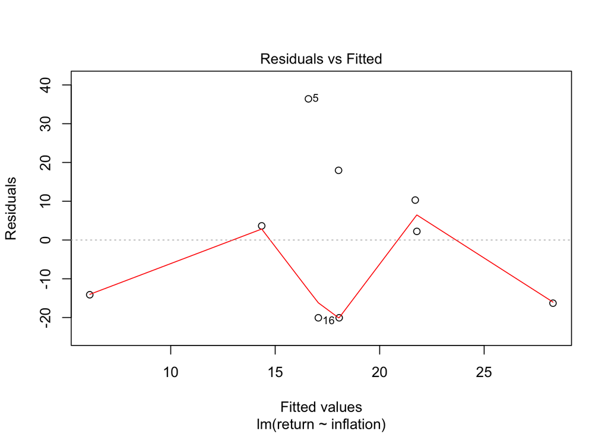

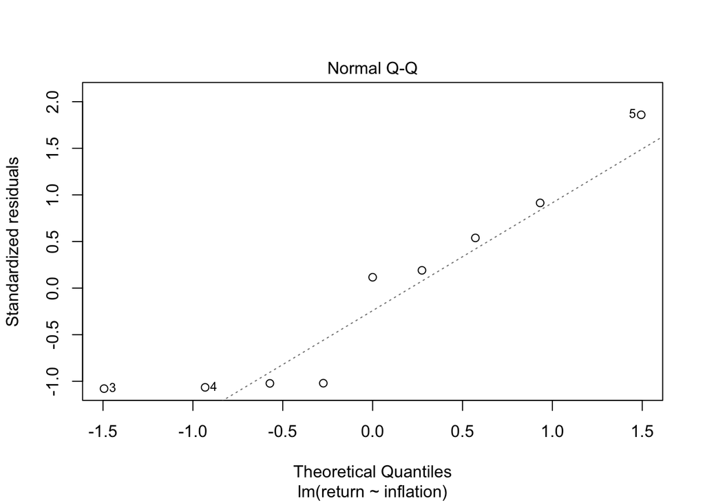

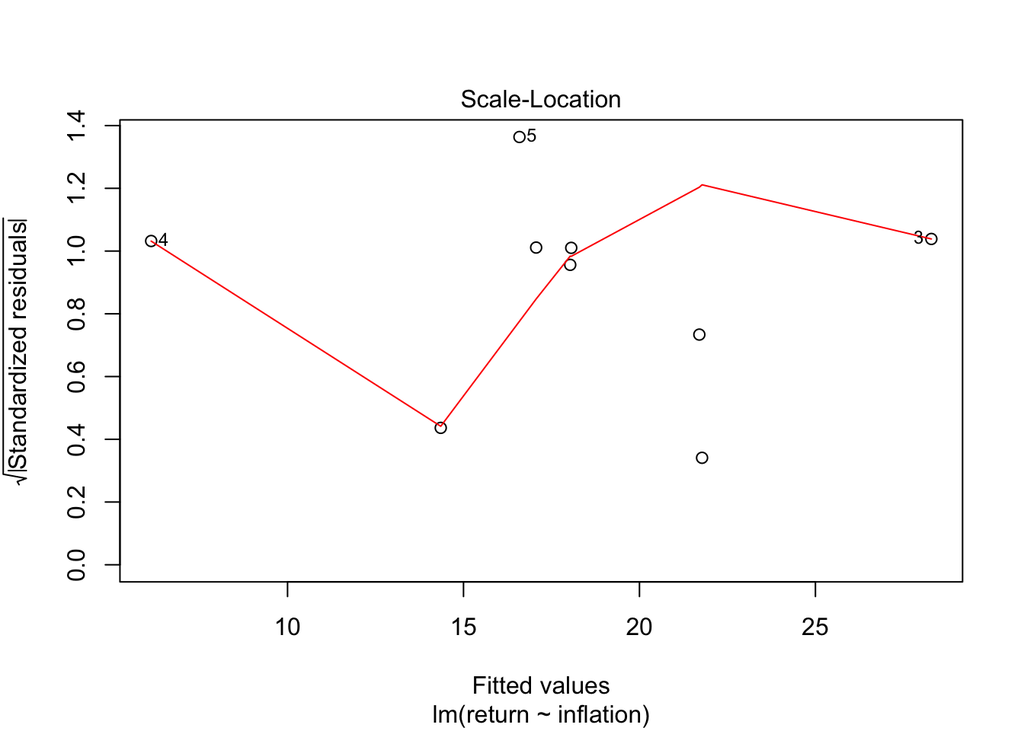

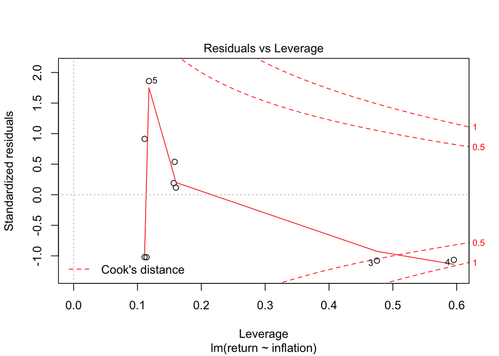

```r
plot(linearMod)
```

#### 10-21

```r
x = c(27,39,73,66,33,43,47,55,60,68,70,75,82)
y = c(2,3,10,9,4,6,5,8,7,9,10,13,12)

data = data.frame("x" = x, "y" = y)

linearMod = lm(y ~ x, data = data)
summary(linearMod)
```

```
##
## Call:
## lm(formula = y ~ x, data = data)
##
## Residuals:
##     Min      1Q  Median      3Q     Max
## -1.2221 -0.6345 -0.2474  0.7917  2.0591
##
## Coefficients:
##             Estimate Std. Error t value Pr(>|t|)
## (Intercept)  -3.0566     0.9710  -3.148  0.00928 **
## x             0.1866     0.0164  11.381    2e-07 ***
## ---
## Signif. codes:  0 '***' 0.001 '**' 0.01 '*' 0.05 '.' 0.1 ' ' 1
##
## Residual standard error: 0.9954 on 11 degrees of freedom
## Multiple R-squared:  0.9217, Adjusted R-squared:  0.9146
## F-statistic: 129.5 on 1 and 11 DF,  p-value: 2.001e-07
```

```r
anova2 = anova(linearMod)
summary(anova2)
```

```
##        Df           Sum Sq          Mean Sq            F value
##  Min.   : 1.0   Min.   : 10.90   Min.   :  0.9908   Min.   :129.5
##  1st Qu.: 3.5   1st Qu.: 40.26   1st Qu.: 32.8261   1st Qu.:129.5
##  Median : 6.0   Median : 69.62   Median : 64.6614   Median :129.5
##  Mean   : 6.0   Mean   : 69.62   Mean   : 64.6614   Mean   :129.5
##  3rd Qu.: 8.5   3rd Qu.: 98.97   3rd Qu.: 96.4968   3rd Qu.:129.5
##  Max.   :11.0   Max.   :128.33   Max.   :128.3321   Max.   :129.5
##                                                     NA's   :1
##      Pr(>F)
##  Min.   :2e-07
##  1st Qu.:2e-07
##  Median :2e-07
##  Mean   :2e-07
##  3rd Qu.:2e-07
##  Max.   :2e-07
##  NA's   :1
```

```r
confint(linearMod,"x",level=0.95)
```

```
##     2.5 %    97.5 %
## x 0.15054 0.2227271
```

- [0.150, 0.222]
- Zero is not plausible

#### 10-39

P = Avg. Price per share x_k = (X/k) contemporaneous earnings per share divided by firm-specific discount rate

H<sub>0</sub>: B<sub>1</sub> = 0 H<sub>1</sub>: B<sub>1</sub> $\neq$ 0

```r
n = 213
b1 = 0.68
s_b1 = 12.03

t = b1 / s_b1
t
```

```
## [1] 0.05652535
```

t = 0.0565, do not reject H<sub>0</sub>. Cannot determine linear relationship based on givens.

#### 10-44

Y = return on stocks X = market value

```r
n = 4921
b1 = -0.0053
s_b1 = 0.0019
```

```r
b1 / s_b1
```

```
## [1] -2.789474
```

2. t = -2.789474
- Reject H<sub>0</sub>
3. -2.789474
4. yes
5. a negative or inverse relationship
6. The repatriation rate decreases as profitability increases
7. There is a inverse relationship between a company’s profitability and the repatriation rate. The null hypothesis was rejected because it is a linear relationship.

#### 10-51

1. A smaple size is needed to determine significance
2. It is a positive, linear relationship
3. The model only explains 2.6% of the variation in call price
4. No, r^2 is too small to use this model

#### 10-63

1. Heteroscedasticity
2. No model inadequacy
3. Moel inadequacy, because the data shows a curve (not linear)

#### 10-64

1. No model inadequacy
2. Yes, it increases with time

#### 10-65

1. No serious inadequacy
2. Yes. A deviation is visable in the model.

#### 10-66

Produce residual plots for regression of problem 10-17. Is there any apparent model inadequency?

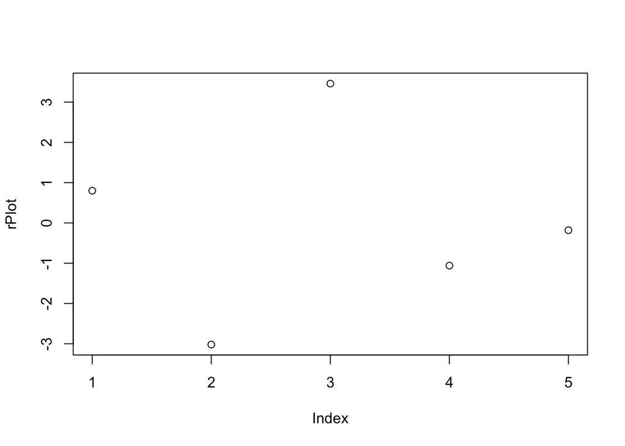

```r
quartile<-c(1,2,3,4,5)
growth<-c(17.3,23.6,40.2,45.8,56.8)
money<-data.frame(quartile,growth)
linRegression<-lm(growth~quartile, data=money)
rPlot<-resid(linRegression)
plot(rPlot)
```

- Seems to have no correlation.

#### 10-69

```r
miles = c(1211,1345,1422,1687,1849,2026,2133,2253,2400,2468,2699,2806,3082,3209,3466,3643,3852,4033,4267,4498,4533,4804,5090,5233,5439)
dollars = c(1802,2405,2005,2511,2332,2305,3016,3385,3090,3694,3371,3998,3555,4692,4244,5298,4801,5147,5738,6420,6059,6426,6321,7026,6964)
american=data.frame(miles, dollars)
attach(american)
express=lm(dollars~miles)
prediction_1 = predict(express,data.frame(miles=5000), interval="prediction",
                 level = 0.95)
prediction_1
```

```
##        fit      lwr      upr
## 1 6551.519 5854.653 7248.385
```

```r
prediction_2 = predict(express,data.frame(miles=4000), interval="prediction",
                 level = 0.95)
prediction_2
```

```
##        fit      lwr      upr
## 1 5296.185 4619.686 5972.683
```

- The 4000 is lower for fit, lwr and upr

#### 10-70

99% prediction income quartile = 5

```r
predict(linRegression, data.frame(quartile=5), interval = "prediction", level = 0.99)
```

```
##     fit      lwr      upr
## 1 56.98 36.57278 77.38722
```

- See R output above

#### 11-4

```r
value = c(345,238,452,422,328,375,660,466,290)
size = c(1650,1870,2230,1740,1900,2000,3200,1860,1230)
distance = c(3.5,0.5,1.5,4.5,1.8,0.1,3.4,3.0,1.0)
home = data.frame("value" = value, "size" = size, "distance" = distance)

multi = lm(value ~ size + distance)
summary(multi)
```

```
##
## Call:
## lm(formula = value ~ size + distance)
##
## Residuals:
##     Min      1Q  Median      3Q     Max
## -91.833 -39.987   9.495  35.075  60.165
##
## Coefficients:
##             Estimate Std. Error t value Pr(>|t|)
## (Intercept)  -9.7997    80.7627  -0.121  0.90738
## size          0.1733     0.0399   4.343  0.00486 **
## distance     31.0940    14.1324   2.200  0.07008 .
## ---
## Signif. codes:  0 '***' 0.001 '**' 0.01 '*' 0.05 '.' 0.1 ' ' 1
##
## Residual standard error: 59.48 on 6 degrees of freedom
## Multiple R-squared:  0.8264, Adjusted R-squared:  0.7685
## F-statistic: 14.28 on 2 and 6 DF,  p-value: 0.005233
```

```r
anov = anova(multi)
anov
```

```
## Analysis of Variance Table
##
## Response: value
##           Df Sum Sq Mean Sq F value   Pr(>F)
## size       1  83908   83908 23.7195 0.002794 **
## distance   1  17125   17125  4.8408 0.070084 .
## Residuals  6  21225    3538
## ---
## Signif. codes:  0 '***' 0.001 '**' 0.01 '*' 0.05 '.' 0.1 ' ' 1
```

- y-intercept = -9.7997
- -9.7997 + 0.1733 s + 31.094 d

## Risk and Return

```r
market<-c(16.02,12.17,11.48,17.62,20.01,14,13.22,17.79,15.46,8.09,11,18.52,14.05,8.79,11.6)
stock<-c(21.05,17.25,13.1,18.23,21.52,13.26,15.84,22.18,16.26,5.64,10.55,17.86,12.75,9.13,13.87)
data<-data.frame(market,stock)
attach(data)
reg<-lm(stock~market,data=data)
```

#### 1)

```r
reg
```

```
##
## Call:
## lm(formula = stock ~ market, data = data)
##
## Coefficients:
## (Intercept)       market
##      -1.091        1.167
```

$\beta$ = 1.167 * -1.091 + 1.167x

#### 2)

- The slope indicates that the stock is barely above the average risk.

#### 3)

```r
confint(reg, "market",level=0.95)
```

```
##            2.5 %  97.5 %
## market 0.7929059 1.54101
```

- See r output above. No, the risk could be below average because the 2.5% is at 0.7929

#### 4)

```r
predict(reg, data.frame(market=10), interval = "prediction")
```

```
##        fit     lwr      upr
## 1 10.57884 5.22192 15.93576
```

- 10.57884

#### 5)

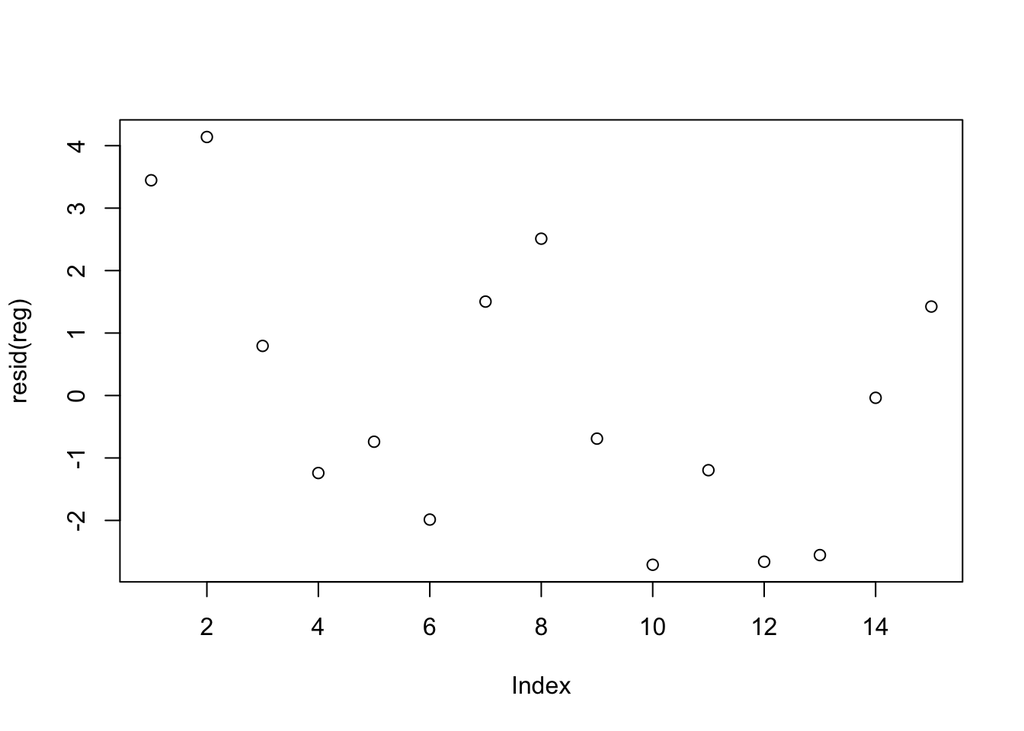

```r
plot(resid(reg))
```

* Appears to have no correlation

#### 6)

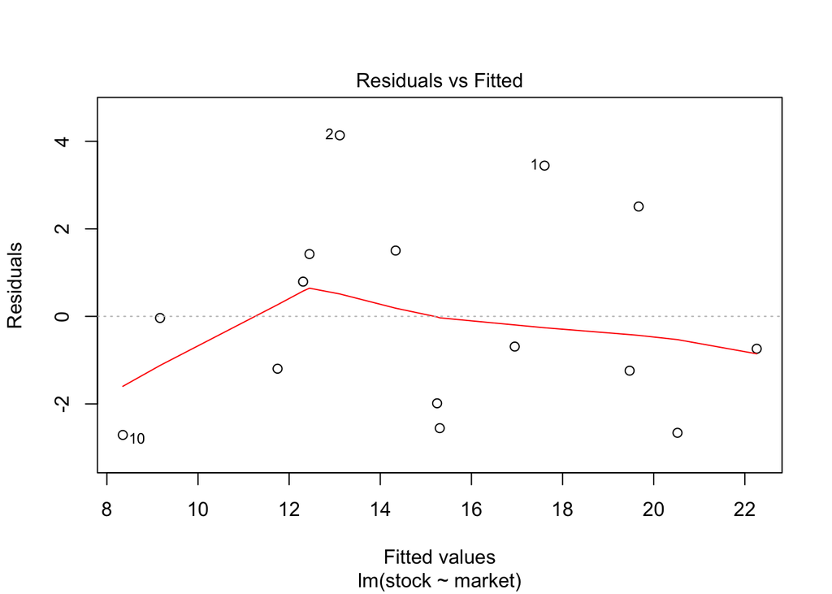

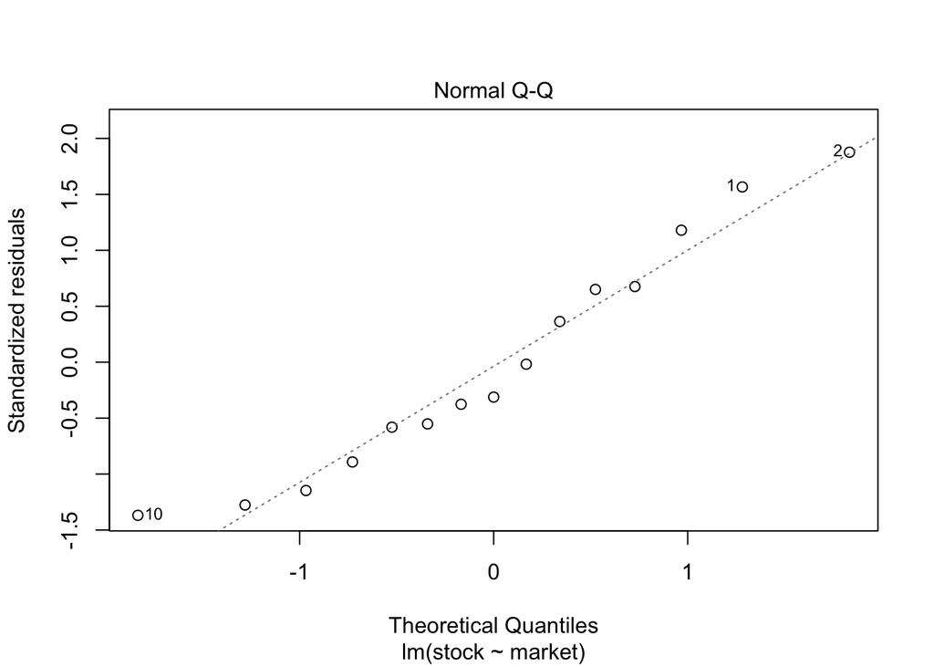

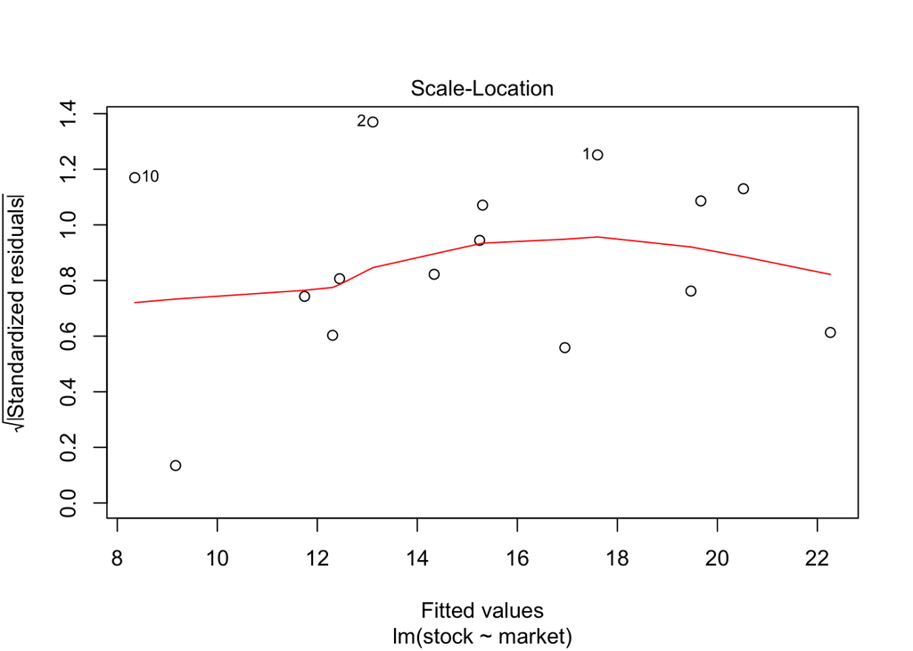

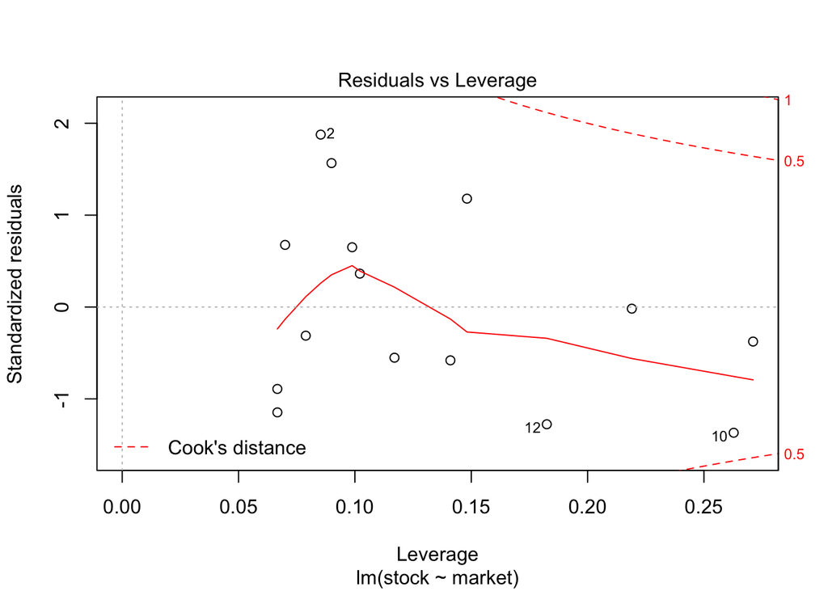

```r
plot(reg)
```

- Yes they appear to be normally distributed